```python
import pandas as pd
import numpy as np
from sklearn.linear_model import LogisticRegression
import matplotlib.pyplot as plt
from matplotlib.image import imread
from sklearn.neighbors import KNeighborsClassifier
from sklearn.model_selection import cross_val_score
from sklearn.preprocessing import StandardScaler
```

# Feature normalization in k-NN (60pt)

### 1.1 Explore data (6pt)

```
1. (1pt) Load the data. Ignore id.
```

```python
# Load the dataset
wdbc = pd.read_csv('/home/jovyan/INFO371PS/Data/wdbc.csv').drop(['id'], axis=1)
# Print the basic info of the dataset
wdbc.info()
# Print the first 5 lines of the dataset
wdbc.head(5)
```

```
<class 'pandas.core.frame.DataFrame'>
RangeIndex: 569 entries, 0 to 568
Data columns (total 31 columns):
 #   Column             Non-Null Count  Dtype
---  ------             --------------  -----
 0   diagnosis          569 non-null    object
 1   radius.mean        569 non-null    float64
 2   texture.mean       569 non-null    float64
 3   perimeter.mean     569 non-null    float64
 4   area.mean          569 non-null    float64
 5   smoothness.mean    569 non-null    float64
 6   compactness.mean   569 non-null    float64
 7   concavity.mean     569 non-null    float64
 8   concpoints.mean    569 non-null    float64
 9   symmetry.mean      569 non-null    float64
```

[output cut: 23 more lines]

|  | diagnosis | radius.mean | texture.mean | perimeter.mean | area.mean | smoothness.mean | compactness.mean | concavity.mean | concpoints.mean | symmetry.mean | ... | radius.worst | texture.worst | perimeter.worst | area.worst | smoothness.worst | compactness.worst | concavity.worst | concpoints.worst | symmetry.worst | fracdim.worst |
| --- | --- | --- | --- | --- | --- | --- | --- | --- | --- | --- | --- | --- | --- | --- | --- | --- | --- | --- | --- | --- | --- |
| 0 | M | 17.99 | 10.38 | 122.80 | 1001.0 | 0.11840 | 0.27760 | 0.3001 | 0.14710 | 0.2419 | ... | 25.38 | 17.33 | 184.60 | 2019.0 | 0.1622 | 0.6656 | 0.7119 | 0.2654 | 0.4601 | 0.11890 |
| 1 | M | 20.57 | 17.77 | 132.90 | 1326.0 | 0.08474 | 0.07864 | 0.0869 | 0.07017 | 0.1812 | ... | 24.99 | 23.41 | 158.80 | 1956.0 | 0.1238 | 0.1866 | 0.2416 | 0.1860 | 0.2750 | 0.08902 |
| 2 | M | 19.69 | 21.25 | 130.00 | 1203.0 | 0.10960 | 0.15990 | 0.1974 | 0.12790 | 0.2069 | ... | 23.57 | 25.53 | 152.50 | 1709.0 | 0.1444 | 0.4245 | 0.4504 | 0.2430 | 0.3613 | 0.08758 |
| 3 | M | 11.42 | 20.38 | 77.58 | 386.1 | 0.14250 | 0.28390 | 0.2414 | 0.10520 | 0.2597 | ... | 14.91 | 26.50 | 98.87 | 567.7 | 0.2098 | 0.8663 | 0.6869 | 0.2575 | 0.6638 | 0.17300 |
| 4 | M | 20.29 | 14.34 | 135.10 | 1297.0 | 0.10030 | 0.13280 | 0.1980 | 0.10430 | 0.1809 | ... | 22.54 | 16.67 | 152.20 | 1575.0 | 0.1374 | 0.2050 | 0.4000 | 0.1625 | 0.2364 | 0.07678 |

5 rows × 31 columns

```
2. (2pt) Create a table where you show ranges (min and max) for each variable. You may include more statistics you consider useful.
```

```python
# Print information about the range and other stat
print(wdbc.describe())
```

```
       radius.mean  texture.mean  perimeter.mean    area.mean  \
count   569.000000    569.000000      569.000000   569.000000
mean     14.127292     19.289649       91.969033   654.889104
std       3.524049      4.301036       24.298981   351.914129
min       6.981000      9.710000       43.790000   143.500000
25%      11.700000     16.170000       75.170000   420.300000
50%      13.370000     18.840000       86.240000   551.100000
75%      15.780000     21.800000      104.100000   782.700000
max      28.110000     39.280000      188.500000  2501.000000

       smoothness.mean  compactness.mean  concavity.mean  concpoints.mean  \
count       569.000000        569.000000      569.000000       569.000000
mean          0.096360          0.104341        0.088799         0.048919
std           0.014064          0.052813        0.079720         0.038803
min           0.052630          0.019380        0.000000         0.000000
25%           0.086370          0.064920        0.029560         0.020310
50%           0.095870          0.092630        0.061540         0.033500
75%           0.105300          0.130400        0.130700         0.074000
max           0.163400          0.345400        0.426800         0.201200

       symmetry.mean  fracdim.mean  ...  radius.worst  texture.worst  \
count     569.000000    569.000000  ...    569.000000     569.000000
mean        0.181162      0.062798  ...     16.269190      25.677223
std         0.027414      0.007060  ...      4.833242       6.146258
min         0.106000      0.049960  ...      7.930000      12.020000
25%         0.161900      0.057700  ...     13.010000      21.080000
50%         0.179200      0.061540  ...     14.970000      25.410000
75%         0.195700      0.066120  ...     18.790000      29.720000
max         0.304000      0.097440  ...     36.040000      49.540000

       perimeter.worst   area.worst  smoothness.worst  compactness.worst  \
count       569.000000   569.000000        569.000000         569.000000
mean        107.261213   880.583128          0.132369           0.254265
std          33.602542   569.356993          0.022832           0.157336
min          50.410000   185.200000          0.071170           0.027290
25%          84.110000   515.300000          0.116600           0.147200
50%          97.660000   686.500000          0.131300           0.211900
75%         125.400000  1084.000000          0.146000           0.339100
max         251.200000  4254.000000          0.222600           1.058000

       concavity.worst  concpoints.worst  symmetry.worst  fracdim.worst
count       569.000000        569.000000      569.000000     569.000000
mean          0.272188          0.114606        0.290076       0.083946
std           0.208624          0.065732        0.061867       0.018061
min           0.000000          0.000000        0.156500       0.055040
25%           0.114500          0.064930        0.250400       0.071460
50%           0.226700          0.099930        0.282200       0.080040
75%           0.382900          0.161400        0.317900       0.092080
max           1.252000          0.291000        0.663800       0.207500

[8 rows x 30 columns]
```

```
3. (3pt) What would be the accuracy of the naive model, such model that predicts every case to the majority category?
```

```python
# Compute the mean of diagnosis is 'B'
print('The accuracy of the naive model is:', (wdbc['diagnosis'] == "B").mean())
```

```
The accuracy of the naive model is: 0.6274165202108963
```

### 1.2 Feature transformation (54pt)

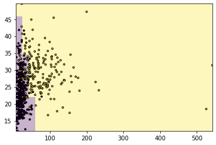

```python
x1 = wdbc["area.se"]
x2 = wdbc["texture.worst"]
y = wdbc.diagnosis == "M"
X = np.column_stack((x1, x2))
m = LogisticRegression(solver="lbfgs").fit(X, y)
# Now greate the regular grid
ex1 = np.linspace(x1.min(), x1.max(), 30) # 30 elements
ex2 = np.linspace(x2.min(), x2.max(), 30)
xx1, xx2 = np.meshgrid(ex1, ex2)
# meshgrid creates two 30x30 matrices
g = np.column_stack((xx1.ravel(), xx2.ravel()))
# we create the design matrix by stacking the xx1, xx2
# after unraveling those into columns
# predict on the grid
hatY = m.predict(g).reshape(30, 30)
# imshow wants a matrix, so we reshape the predicted
# vector into one
_ = plt.imshow(hatY, extent=(x1.min(), x1.max(), x2.min(), x2.max()),
aspect="auto", # let the image fit to screen
interpolation='none', origin='lower', alpha=0.3)
# you need to specify that the image begins from below,
# not above, otherwise it will be flipped around
_ = plt.scatter(x1, x2, c=y, edgecolor='k', s=8)
_ = plt.show()
```

```
1. (12pt) Pick features texture.mean and concpoints.mean and do the following:
```

```
(a) Use these two to model diagnosis with k-NN where k=7 using original features (i.e. not normalized features).
```

```python
# Define knn which takes 7 k-s
knn = KNeighborsClassifier(n_neighbors=7)
```

```
(b) (6pt) Plot the corresponding decision boundary (use at least 100 ×100 matrix). Explain why do you see apparently arbitrary stripes on the image (vertical stripes in case you put texture on x-axis).
```

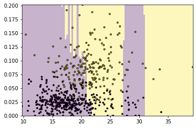

```python
x1 = wdbc["texture.mean"]
x2 = wdbc["concpoints.mean"]
y = wdbc.diagnosis == "M"
X = np.column_stack((x1, x2))
m = knn.fit(X, y)
# Make a function graph that takes x1, x2, y, and m and return the plot
def graph(x1, x2, y, m):
    # Now create the regular grid
    ex1 = np.linspace(x1.min(), x1.max(), 100) # 100 elements
    ex2 = np.linspace(x2.min(), x2.max(), 100)
    xx1, xx2 = np.meshgrid(ex1, ex2)
    # meshgrid creates two 30x30 matrices
    g = np.column_stack((xx1.ravel(), xx2.ravel()))
    # we create the design matrix by stacking the xx1, xx2
    # after unraveling those into columns
    # predict on the grid
    hatY = m.predict(g).reshape(100, 100)
    # imshow wants a matrix, so we reshape the predicted vector into one
    _ = plt.imshow(hatY, extent=(x1.min(), x1.max(), x2.min(), x2.max()),
        aspect="auto", interpolation='none', origin='lower',
        # you need to specify that the image begins from below, not above, otherwise it will be flipped around
        alpha=0.3)
    _ = plt.scatter(x1, x2, c=y, edgecolor='k', s=8)
    _ = plt.show()

graph(x1, x2, y, m)
```

We see apparently arbitrary stripes on the image because the vertical axis scale is more than 10x smaller than the horizontal sclae. When plotting, this large different in scalling is reflected in the vertical stripes.

```
(c) (2pt) Cross-validate your prediction accuracy.
```

```python
# Report the cross-validation scores
scores = cross_val_score(knn, X, y, cv=10, scoring='accuracy')
print('Prediction Accuracy', scores.mean())
```

```
Prediction Accuracy 0.7114974937343359
```

```
2. (5pt) Now normalize these two features and repeat the previous steps.
```

```
Prediction Accuracy 0.9208646616541353
```

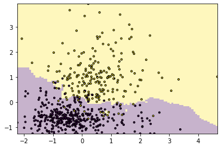

```python
# Normalize the two features and repeat the previous steps
scaler = StandardScaler()
X = scaler.fit_transform(X)
scores = cross_val_score(knn, X, y, cv=10, scoring='accuracy')
print('Prediction Accuracy', scores.mean())
m = knn.fit(X, y)
graph(X[:, 0], X[:, 1], y, m)
```

```
3. (10pt) Explain why does the decision boundary plot look different now. Comment on the accuracy: was accuracy better with original features or normalized features?
```

The decision boundary plot looks very different using the original features versus the normalized features. In the plot using normalized features, the decision boundary appears to be much neater and more accurate in terms of the plot points. This is because when we normalize texture.mean and concpoints.mean, we bring the features to the same scale. This makes it easier to understand their effects. The accuracy is significantly better with the normalized features because of this reason.

```
4. (10pt) now use the original (non-normalized) features and repeat the process. However, this time use Mahalanobis distance.
```

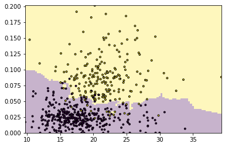

```
Prediction Accuracy 0.9261278195488721
```

```python
x1 = wdbc["texture.mean"]
x2 = wdbc["concpoints.mean"]
X = np.column_stack((x1, x2))
Sigma = np.cov(X, rowvar=False)
knn = KNeighborsClassifier(n_neighbors=7, metric='mahalanobis', metric_params={'V':Sigma})
m = knn.fit(X, y)
graph(wdbc["texture.mean"], wdbc["concpoints.mean"], y, m)
scores = cross_val_score(knn, X, y, cv=10, scoring='accuracy')
print('Prediction Accuracy', scores.mean())
```

```
5. (7pt) Repeat all these steps with a few other sets of two features and a few other k-s of your choice.
```

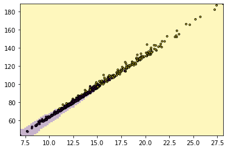

```
Prediction Accuracy 0.8999060150375942
```

```python
x1 = wdbc["radius.mean"]
x2 = wdbc["perimeter.mean"]
X = np.column_stack((x1, x2))
y = wdbc.diagnosis == "M"
Sigma = np.cov(X, rowvar=False)
knn = KNeighborsClassifier(n_neighbors=7, metric='mahalanobis', metric_params={'V':Sigma})
m = knn.fit(X, y)
graph(x1, x2, y, m)
scores = cross_val_score(knn, X, y, cv=10, scoring='accuracy')
print('Prediction Accuracy', scores.mean())
```

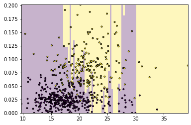

```
Prediction Accuracy 0.6832706766917294
```

```python
x1 = wdbc["texture.mean"]
x2 = wdbc["concpoints.mean"]
y = wdbc.diagnosis == "M"
X = np.column_stack((x1, x2))
m = KNeighborsClassifier(n_neighbors=5).fit(X, y)
graph(x1, x2, y, m)
scores = cross_val_score(knn, X, y, cv=10, scoring='accuracy')
print('Prediction Accuracy', scores.mean())
```

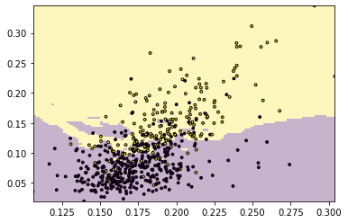

```
Prediction Accuracy 0.7786027568922306
```

```python
x1 = wdbc["symmetry.mean"]
x2 = wdbc["compactness.mean"]
X = np.column_stack((x1, x2))
y = wdbc.diagnosis == "M"
knn = KNeighborsClassifier(n_neighbors=5)
m = knn.fit(X, y)
graph(x1, x2, y, m)
scores = cross_val_score(knn, X, y, cv=10, scoring='accuracy')
print('Prediction Accuracy', scores.mean())
```

```
6. (10pt) Describe your observations. How well do original/normalized/Mahalanobis-transformed features work? Does it depend on the features? Does the visual impression from images align with the cross-validation results?
```

Based on my observations, it appears that mahalanobis-transformed is better than the normalized features, and the normalized ones are better than the original. That makes sense since many of these features are correlated. It depends on the features but without much variations though. The visual impression from images align with the cross-validation results.

# Images: Reduce number of colors (40pt)

```
1. (8pt) Get a color image you like, load it as matrix, and display it using matplotlib. You may use the code along these lines:
```

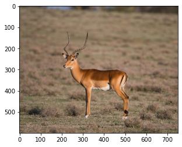

```python
pixels = imread("/home/jovyan/INFO371PS/Data/impala.jpg")
ax = plt.subplot(1,1,1)
ax.set_aspect("equal")
_ = plt.imshow(pixels)
_ = plt.show()
```

```
(450000, 3)
center color values:
 [[132.92932867 113.01647145  90.54290711]
 [ 70.50058447  58.9623874   44.586674  ]
 [157.51793824  95.66053588  46.05313351]
 [175.30385306 152.35076862 131.04332202]
 [109.16561421  92.62565714  72.25066103]
 [142.2926666  120.77532493  97.64676532]
 [161.1900129  136.88983143 114.34089071]
 [199.93751795 130.87388681  76.00962367]
 [ 51.10749027  34.20103761  20.66245136]
 [ 92.09064495  78.00195294  59.40911689]
 [109.52021196  57.65844058  20.1650265 ]
 [223.987807   158.74917262 108.47866225]
 [124.18094089 130.98250905 153.70144753]
 [122.47956273 104.16342455  82.69633951]
 [225.68818636 194.30682196 169.06622296]
 [151.19392486 128.60061412 105.07112536]]
```

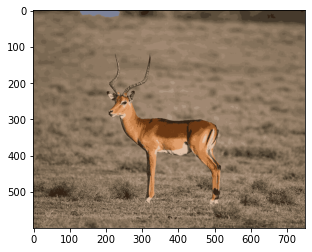

```python
pixels.shape
# convert the ’pixels’ matrix into Nx3 (or Nx4) matrix
# where N is the number of pixels, and 3 or 4 is the number
# of color channels
# so each row is a pixel, and the row data is its color value
## (699, 960, 3)
M = pixels.reshape((-1,pixels.shape[2]))
print(M.shape)
# 3 (or 4) columns, one for each color channel
## (671040, 3)
from sklearn.cluster import KMeans
m = KMeans(16).fit(M) # cluster the color values
cl = m.predict(M) # find the cluster id for each pixel
centers = m.cluster_centers_ # find the cluster centers (i.e. colors)
print("center color values:\n", centers)
## center color values:
## [[167.80836669 114.47089672 66.84755805]
## [120.93002467 130.09952767 49.78606979]
## [ 87.50027963 90.54179925 32.3785363 ]
## [159.3271217 160.8291537 79.38992526]
## [201.71628895 186.7368272 158.56565156]
## [131.06205292 123.57764371 71.23068172]
## [197.83701023 168.13350118 121.62341463]
## [101.33542132 113.14335826 36.16974404]
## [ 66.08828199 74.82737906 16.28670477]
## [190.56134612 138.61481954 91.40713533]
## [149.97296129 140.30899027 89.31257073]
## [ 43.16752119 47.11355906 6.37296309]
## [226.62492314 221.77208444 215.41975815]
## [171.8453769 164.22874226 106.08018364]
## [139.91184987 145.77570987 63.90087152]
## [114.42115074 103.93644784 54.04729418]]
compressed = centers[cl]/255 # normalize to between 0 and 1
compressed = compressed.reshape(pixels.shape)
# make it back to NxM array
ax = plt.subplot(1,1,1)
ax.set_aspect("equal")
_ = plt.imshow(compressed)
_ = plt.show()
```

```python
pixels.shape
```

```
(600, 750, 3)
```

```
2. (24pt) Get this code to work with your image and understand what it does. Explain:
```

```
(a) What does shape of pixels mean
```

The shape of the pixels presents height, width, and number of color channels.

```
(b) What is matrix M? Why does it have 671040 rows and 3 columns in this example?
```

Matrix m is the result of converting the 'pixel' matrix into an Nx3 matrix, where N is the number of pixels, and 3 is the number of color channels. Each row is a pixel. That is why there are 450000 rows in the particular picture I selected since it is 600x750. In the picture provided in the problem set, there are 671040 rows because it is an image that is 699x960 which gives 671040 pixels in total. 3 indicates that there are three color channels.

```
(c) What do cl values tell us? E.g. if cl[12345] = 2, what does it mean?
```

The cl values find the cluster id for each pixel. If cl[12345] = 2, that means pixel 12345 is in cluster 2

```
(d) What are the columns of “center color values” printed above? E.g. the first row, second column is value 163.37. What does that number mean?
```

The columns of "center color values" represent the RGB values for each color. The first row, second column value 163.37 represents the Green value.

```
(e) How many “center color values” are there? Why do we have this number?
```

In the example image provided in the problem set, there are 48 center color values because there are 48 RGB values (16 colors) in the image.

```
3. (8pt) Next repeat the above by reducing the number of colors to 2, and 4. Show the pictures!
Hint: make a function that takes the number of colors as an argument, then you don’t have to copy-paste your code that much.
```

```python
# Make a function that takes un the number of colors and return the image
def print_image(num_color):
    M = pixels.reshape((-1,pixels.shape[2]))
    from sklearn.cluster import KMeans
    m = KMeans(num_color).fit(M) # cluster the color values
    cl = m.predict(M) # find the cluster id for each pixel
    centers = m.cluster_centers_ # find the cluster centers (i.e. colors)
    compressed = centers[cl]/255 # normalize to between 0 and 1
    compressed = compressed.reshape(pixels.shape)
    # make it back to NxM array
    ax = plt.subplot(1,1,1)
    ax.set_aspect("equal")
    _ = plt.imshow(compressed)
    _ = plt.show()
```

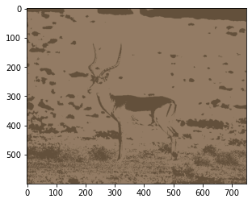

```python
# Reduce the number of colors to 2
print_image(2)
```

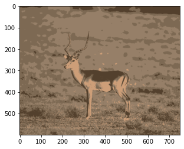

```python
# Reduce the number of colors to 4
print_image(4)
```